# Temperature (springs/wells) vs. Specific Conductance (creek) Correlation

Exploratory, pairwise lagged cross-correlation across spatially distinct monitoring sites

Published

September 5, 2026

## 1 Purpose and scope

This notebook correlates two **independently-collected** time series — temperature at spring/well loggers and specific conductance at the two creek conductivity loggers — to look for a relationship between thermal and conductivity signals at spatially distinct points. This is deliberately **not** a structural join into one table (unlike `02_sc_discharge_weather.qmd`’s SC/discharge/precipitation view) — it’s a correlation analysis between two datasets that were never designed to be merged.

**Warning**

This is exploratory by construction: every temperature-logger site is compared against every conductivity-logger site, which means several pairwise comparisons are being run at once. No individual correlation below should be read as “significant” without correcting for that — the purpose here is to see which pairs look worth a closer, targeted look, not to draw a conclusion from this notebook alone. One pair (`SBRR`) has **both** a temperature logger and a conductivity logger at the same physical location, which is the most directly interpretable comparison in this set — treat cross-site pairs more cautiously than that one.

Also note: both temperature and specific conductance show a diurnal cycle (see `01_conductivity_temporal_structure.qmd`). A raw cross-correlation can pick up shared diurnal timing rather than a real hydrologic link between the two signals — this is not addressed by detrending below, so a strong correlation at short lags should be interpreted with that in mind.

```r
library(knitr)
opts_knit$set(root.dir = normalizePath(file.path(getwd(), "..")))
```

```r
library(DBI)
library(RSQLite)
library(dplyr)
library(ggplot2)
library(tidyr)

db_path <- file.path("database", "geochem_operational.sqlite")
if (!file.exists(db_path)) db_path <- file.path("database", "geochem_demo.sqlite")
con <- dbConnect(SQLite(), db_path, flags = SQLITE_RO)
```

## 2 Load daily-mean series

```r
temp_daily <- dbGetQuery(con, "
  SELECT
    l.external_station_code AS site,
    date(datetime(t.timestamp, 'unixepoch')) AS date,
    AVG(t.temperature) AS temp_c_mean
  FROM Temperature_Observations t
  JOIN Temperature_Loggers tl ON t.logger_id = tl.logger_id
  LEFT JOIN Locations l ON tl.location_id = l.location_id
  WHERE l.external_station_code IS NOT NULL
  GROUP BY l.external_station_code, date(datetime(t.timestamp, 'unixepoch'))
")

sc_daily <- dbGetQuery(con, "SELECT date, external_station_code AS site, sc_25c_mean FROM vw_sc_discharge_daily")

dbDisconnect(con)

temp_daily$date <- as.Date(temp_daily$date)
sc_daily$date <- as.Date(sc_daily$date)

temp_sites <- sort(unique(temp_daily$site))
sc_sites <- sort(unique(sc_daily$site))

message(length(temp_sites), " temperature site(s): ", paste(temp_sites, collapse = ", "))
```

```
9 temperature site(s): SBF_0001, SBRR, SBS_0001, SBS_0002, SBS_0003, SBS_0004, SBS_0006, SBW_0001, SBW_0002
```

```r
message(length(sc_sites), " conductivity site(s): ", paste(sc_sites, collapse = ", "))
```

```
2 conductivity site(s): SBGG, SBRR
```

## 3 Pairwise lagged cross-correlation

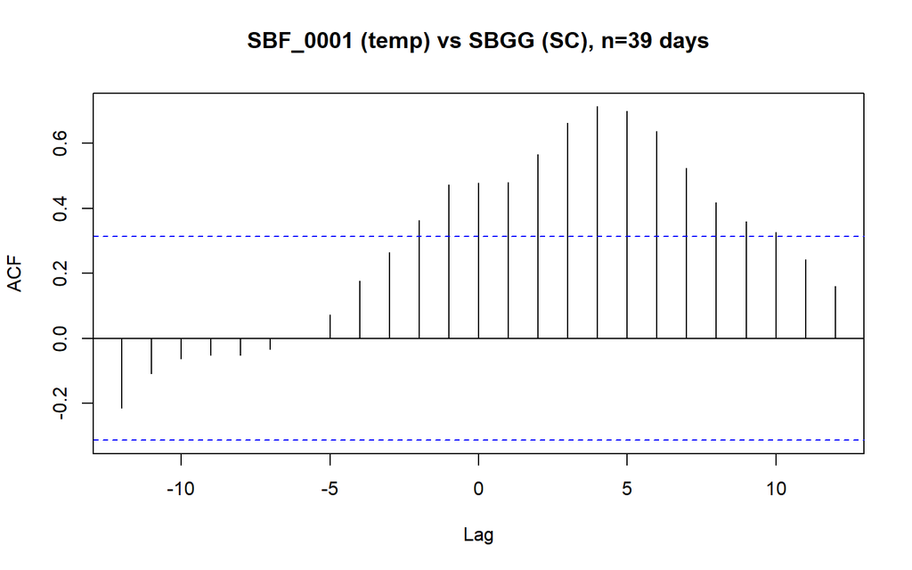

Cross-correlation, temperature site vs. conductivity site (only pairs with >= 14 overlapping days shown)

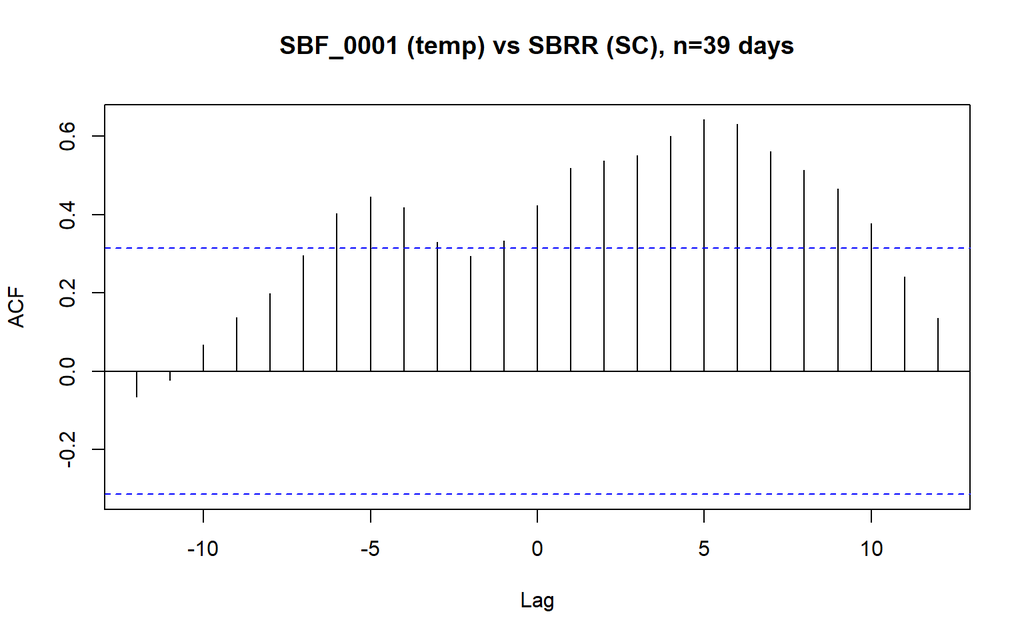

Cross-correlation, temperature site vs. conductivity site (only pairs with >= 14 overlapping days shown)

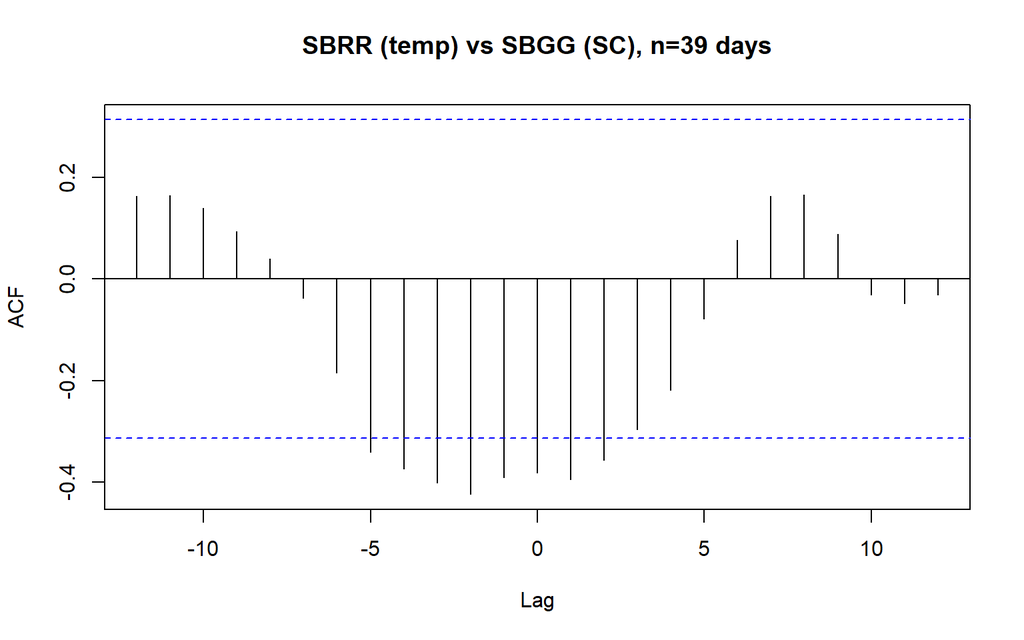

Cross-correlation, temperature site vs. conductivity site (only pairs with >= 14 overlapping days shown)

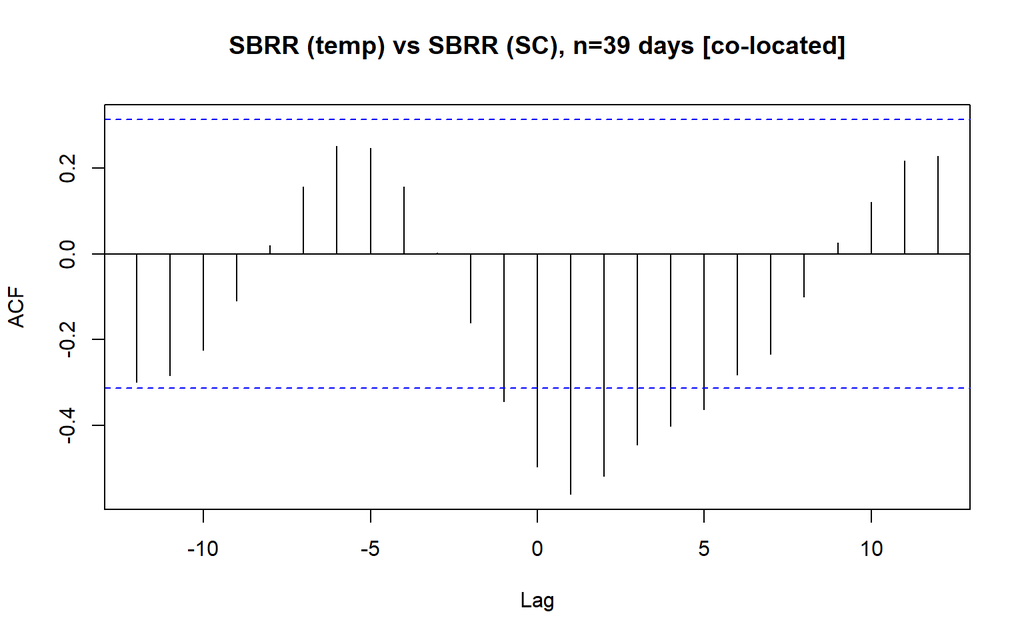

Cross-correlation, temperature site vs. conductivity site (only pairs with >= 14 overlapping days shown)

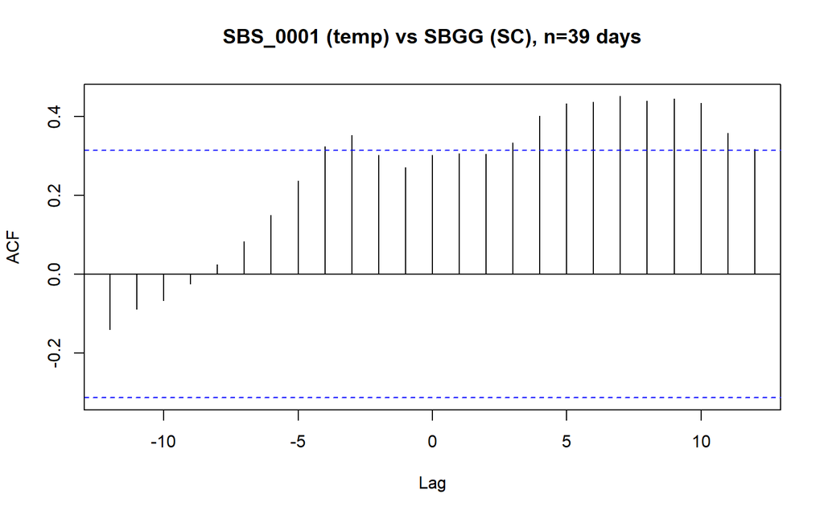

Cross-correlation, temperature site vs. conductivity site (only pairs with >= 14 overlapping days shown)

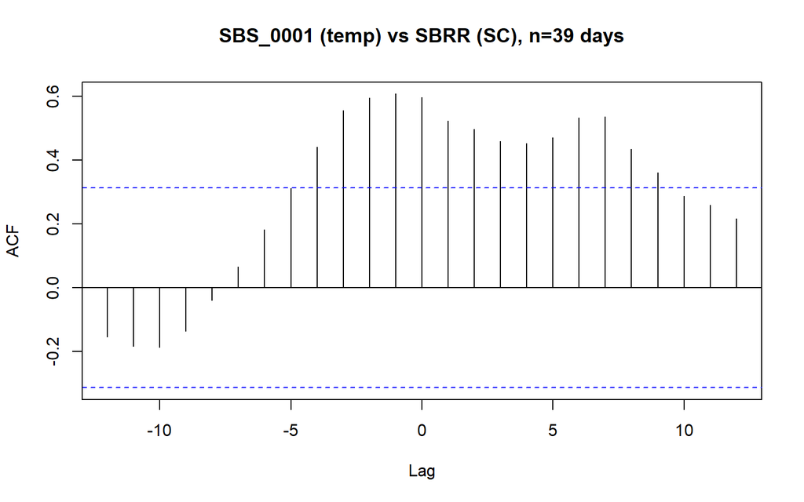

Cross-correlation, temperature site vs. conductivity site (only pairs with >= 14 overlapping days shown)

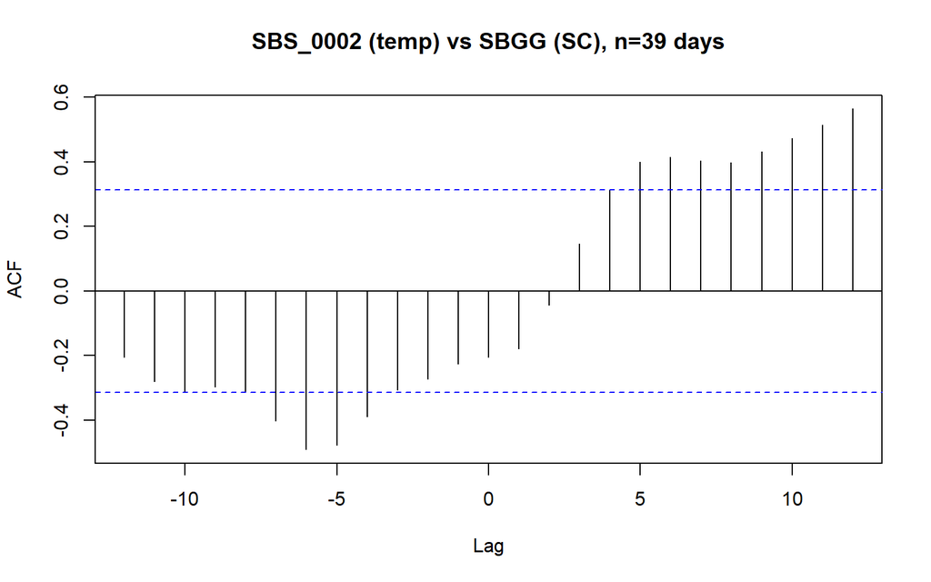

Cross-correlation, temperature site vs. conductivity site (only pairs with >= 14 overlapping days shown)

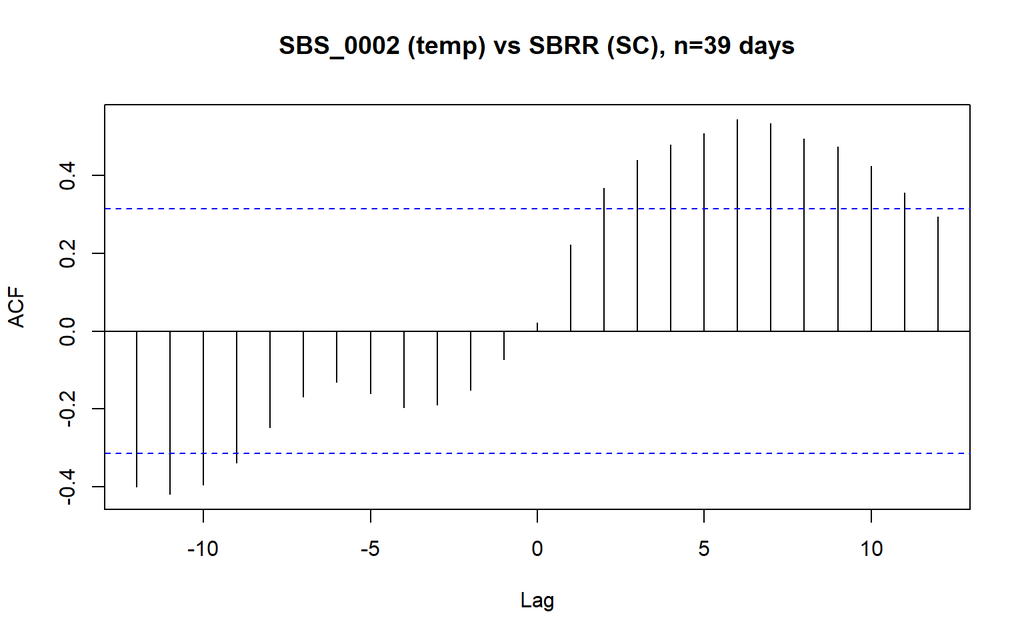

Cross-correlation, temperature site vs. conductivity site (only pairs with >= 14 overlapping days shown)

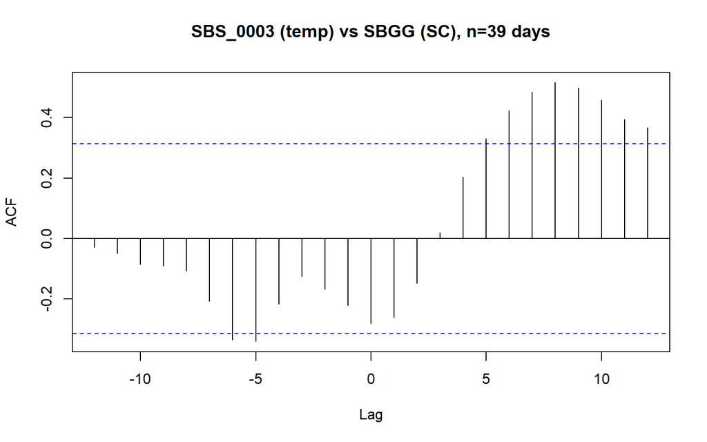

Cross-correlation, temperature site vs. conductivity site (only pairs with >= 14 overlapping days shown)

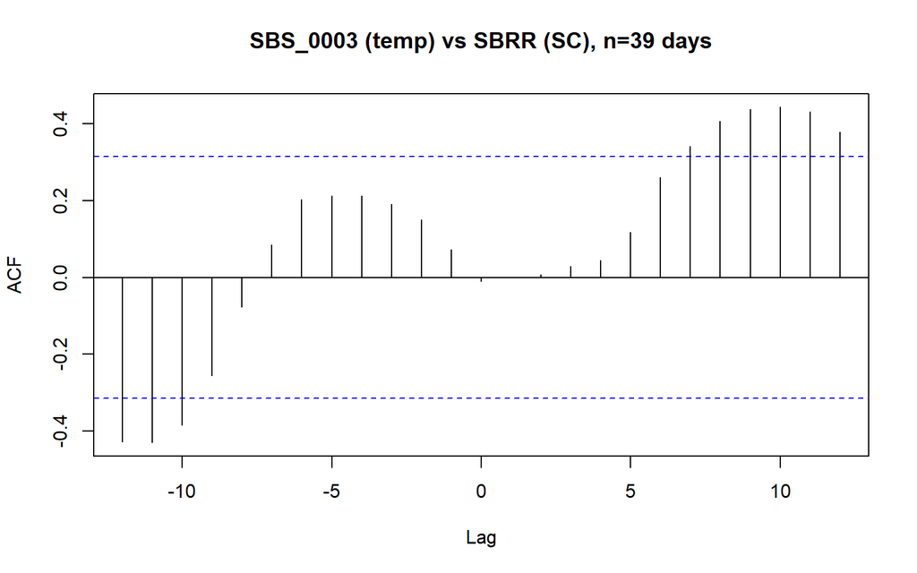

Cross-correlation, temperature site vs. conductivity site (only pairs with >= 14 overlapping days shown)

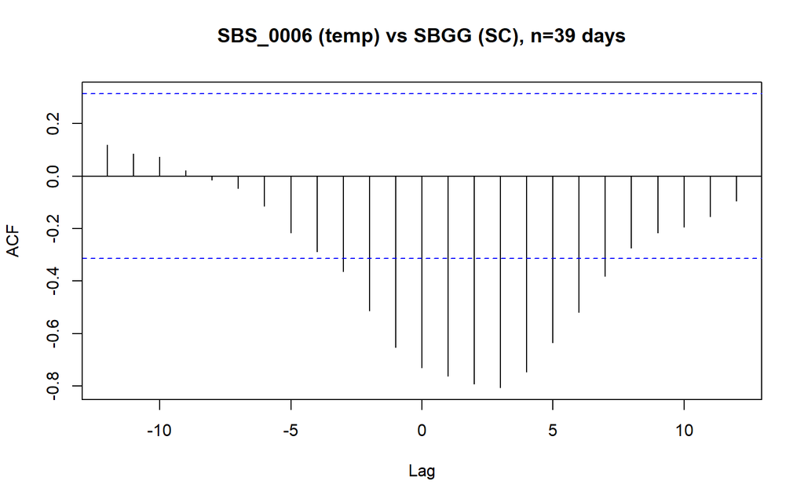

Cross-correlation, temperature site vs. conductivity site (only pairs with >= 14 overlapping days shown)

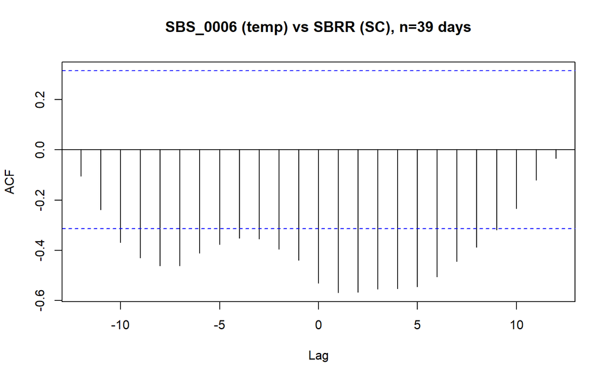

Cross-correlation, temperature site vs. conductivity site (only pairs with >= 14 overlapping days shown)

[4 more figures not shown]

```r
min_overlap_days <- 14
pair_summary <- list()

for (t_site in temp_sites) {
  for (s_site in sc_sites) {

    joined <- temp_daily |>
      filter(site == t_site) |>
      select(date, temp_c_mean) |>
      inner_join(sc_daily |> filter(site == s_site) |> select(date, sc_25c_mean), by = "date") |>
      arrange(date)

    if (nrow(joined) < min_overlap_days) {
      pair_summary[[length(pair_summary) + 1]] <- data.frame(
        temp_site = t_site, sc_site = s_site, n_overlap_days = nrow(joined),
        max_abs_ccf = NA_real_, lag_at_max = NA_integer_
      )
      next
    }

    cc <- ccf(joined$temp_c_mean, joined$sc_25c_mean, plot = FALSE, na.action = na.pass)
    i_max <- which.max(abs(cc$acf))

    plot(cc, main = paste0(t_site, " (temp) vs ", s_site, " (SC), n=", nrow(joined), " days",
                            if (t_site == s_site) " [co-located]" else ""))

    pair_summary[[length(pair_summary) + 1]] <- data.frame(
      temp_site = t_site, sc_site = s_site, n_overlap_days = nrow(joined),
      max_abs_ccf = round(cc$acf[i_max], 3), lag_at_max = cc$lag[i_max]
    )
  }
}
```

```r
pair_summary <- do.call(rbind, pair_summary)
```

## 4 Summary table

```r
pair_summary |>
  arrange(desc(abs(max_abs_ccf)))
```

```
   temp_site sc_site n_overlap_days max_abs_ccf lag_at_max
1   SBS_0006    SBGG             39      -0.807          3
2   SBF_0001    SBGG             39       0.713          4
3   SBF_0001    SBRR             39       0.642          5
4   SBW_0002    SBRR             39      -0.633          0
5   SBS_0001    SBRR             39       0.608         -1
6   SBS_0006    SBRR             39      -0.568          1
7   SBS_0002    SBGG             39       0.564         12
8       SBRR    SBRR             39      -0.561          1
9   SBS_0002    SBRR             39       0.543          6
10  SBW_0001    SBRR             39      -0.518          0
11  SBS_0003    SBGG             39       0.516          8
12  SBW_0002    SBGG             39      -0.456         -2
13  SBS_0001    SBGG             39       0.451          7
14  SBS_0003    SBRR             39       0.443         10
15      SBRR    SBGG             39      -0.424         -2
16  SBW_0001    SBGG             39      -0.396         -3
17  SBS_0004    SBGG              0          NA         NA
18  SBS_0004    SBRR              0          NA         NA
```

## 5 Status and next steps

- This ran on 665 temperature-daily rows across 9 site(s) and 78 SC-daily rows across 2 site(s) — re-run as the logger deployment continues to accumulate more overlapping record.
- The `SBRR` pair (temperature logger + conductivity logger co-located) is the one result here worth following up on directly if it shows a notable correlation — everything else is a genuinely exploratory, multiple-comparisons screen.
- If a pair does look promising on repeated runs, the sensible next step is a proper detrended/deseasonalized correlation (e.g. on STL remainder components from `01_conductivity_temporal_structure.qmd`) rather than the raw series used here, to rule out shared diurnal timing as the explanation.